# Studying patterns of F1 circuits

Spring 2025 Data Science Project  
Jake Farr, Viktor Rakov, Ryan Henrikson

## Contributions:

### Viktor Rakov:

- **Project Idea**: has personal interest in F1, and suggested working with F1 data.
- **Dataset Curation and Preprocessing**: found the f1db database, and collected the database files.
- **Data Exploration and Summary Statistics**: did basic data exploration, and performed hypothesis tests on our data.
- **ML Algorithm Design/Development**: suggested using KFolds rather than LOOCV, which often produced better results.
- **ML Algorithm Training and Test Data Analysis**: Tested various model types using KFolds.

### Ryan Henrikson

- **Data Exploration and Summary Statistics**: assisted with hypothesis testing, interpretation of results.
- **ML Algorithm Design/Development**: contributed to testing models, provided input on how to improve/tweak our model design
- **Visualization, Result Analysis, Conclusion**: rimary contributor to final visualization and result analysis, as well as writing out the conclusion.
- **Final Tutorial Report Creation**: spent lots of time proofreading entire notebook, contributing tweaks and improving clarity.

## Introduction

For our project, we knew that we wanted our general topic to be Formula One, but after some deliberation we settled on a specific question: **could we predict the average lap time of a circuit using machine learning?**

We felt that this idea was more original than just trying to guess race times or outcomes, and we believe that a model like this could be useful for F1 circuit design, allowing a circuit designer to get more insight to how the circuit they want to design might behave, before investing millions into the project.

## Dataset Curation and Preprocessing

Our data is sourced from f1db, a very comprehensive database about all things F1. We used a python script to save this data locally, and then uploaded it to our google drives.

```python
# Import Google Drive
from google.colab import drive
drive.mount('/content/drive/', force_remount=True)

# Import libraries
import pandas as pd
import matplotlib as mp
import seaborn as sea
import matplotlib.pyplot as plt
```

## Exploratory Data Analysis

Let's get some information about the circuits in our data:

```python
circuits_df = pd.read_csv('drive/MyDrive/CMSC320_Data/f1db-circuits.csv')
circuits_df
```

|  | id | name | fullName | previousNames | type | direction | placeName | countryId | latitude | longitude | length | turns | totalRacesHeld |
| --- | --- | --- | --- | --- | --- | --- | --- | --- | --- | --- | --- | --- | --- |
| 0 | adelaide | Adelaide | Adelaide Street Circuit | NaN | STREET | CLOCKWISE | Adelaide | australia | -34.927222 | 138.617222 | 3.780 | 16 | 11 |
| 1 | aida | Aida | Okayama International Circuit | TI Circuit Aida | RACE | CLOCKWISE | Aida | japan | 34.915000 | 134.221111 | 3.703 | 13 | 2 |
| 2 | ain-diab | Ain-Diab | Ain-Diab Circuit | NaN | ROAD | CLOCKWISE | Casablanca | morocco | 33.578611 | -7.687500 | 7.618 | 18 | 1 |
| 3 | aintree | Aintree | Aintree Motor Racing Circuit | NaN | ROAD | CLOCKWISE | Aintree | united-kingdom | 53.476944 | -2.940556 | 4.828 | 8 | 5 |
| 4 | anderstorp | Anderstorp Raceway | Anderstorp Raceway | Scandinavian Raceway | RACE | CLOCKWISE | Anderstorp | sweden | 57.264167 | 13.601389 | 4.031 | 8 | 6 |
| ... | ... | ... | ... | ... | ... | ... | ... | ... | ... | ... | ... | ... | ... |
| 72 | yas-marina | Yas Marina | Yas Marina Circuit | NaN | RACE | ANTI_CLOCKWISE | Abu Dhabi | united-arab-emirates | 24.467222 | 54.603056 | 5.281 | 16 | 16 |
| 73 | yeongam | Korea | Korea International Circuit | NaN | RACE | ANTI_CLOCKWISE | Yeongam | south-korea | 34.733333 | 126.416667 | 5.615 | 18 | 4 |
| 74 | zandvoort | Zandvoort | Circuit Park Zandvoort | NaN | RACE | CLOCKWISE | Zandvoort | netherlands | 52.388819 | 4.540922 | 4.259 | 14 | 34 |
| 75 | zeltweg | Zeltweg | Zeltweg | NaN | ROAD | CLOCKWISE | Zeltweg | austria | 47.202222 | 14.742222 | 3.186 | 4 | 1 |
| 76 | zolder | Zolder | Circuit Zolder | NaN | RACE | CLOCKWISE | Heusden-Zolder | belgium | 50.988889 | 5.255556 | 4.262 | 15 | 10 |

77 rows × 13 columns

```python
circuits_df.shape
```

```
(77, 13)
```

It looks like there are 77 circuits, with various information such as number of turns, direction, name, country, and number of races

```python
circuits_df.dtypes
```

|  | 0 |
| --- | --- |
| id | object |
| name | object |
| fullName | object |
| previousNames | object |
| type | object |
| direction | object |
| placeName | object |
| countryId | object |
| latitude | float64 |
| longitude | float64 |
| length | float64 |
| turns | int64 |
| totalRacesHeld | int64 |

**dtype:** object

The data types all make sense, so we shouldn't need to correct those.

I want to get descriptive statistics for track length, total races held, and number of turns, so let's clean that data.

```python
# Drop rows that don't have the data we need (drops <1%)
circuits_df = circuits_df.dropna(subset=['length', 'turns', 'totalRacesHeld'])

# Clarify length units (found through external research of circuits)
circuits_df = circuits_df.rename(columns={'length': 'length_in_km'})

# Convert to miles, since we're Americans
circuits_df['length_in_mi'] = circuits_df['length_in_km'] * 0.621371
```

```python
circuits_df['length_in_mi'].describe()
```

|  | length_in_mi |
| --- | --- |
| count | 77.000000 |
| mean | 3.306331 |
| std | 1.643837 |
| min | 1.979688 |
| 25% | 2.614108 |
| 50% | 3.050310 |
| 75% | 3.488998 |
| max | 15.894049 |

**dtype:** float64

```python
circuits_df['turns'].describe()
```

|  | turns |
| --- | --- |
| count | 77.000000 |
| mean | 15.155844 |
| std | 5.878294 |
| min | 4.000000 |
| 25% | 12.000000 |
| 50% | 15.000000 |
| 75% | 18.000000 |
| max | 48.000000 |

**dtype:** float64

```python
circuits_df['totalRacesHeld'].describe()
```

|  | totalRacesHeld |
| --- | --- |
| count | 77.000000 |
| mean | 14.610390 |
| std | 16.833672 |
| min | 1.000000 |
| 25% | 3.000000 |
| 50% | 8.000000 |
| 75% | 20.000000 |
| max | 74.000000 |

**dtype:** float64

There are some interesting insights from this data:

1. While the average track length is 3.31mi, there is a very wide range of (1.98mi, 15.89mi)
2. The average track has about 15 turns, but one track has only 4 and another has 48!
3. Each track in our data has held at least 1 race.

Overall, it is clear that F1 tracks come in many shapes and sizes.

To conclude, I want to plot the lengths of the various tracks.

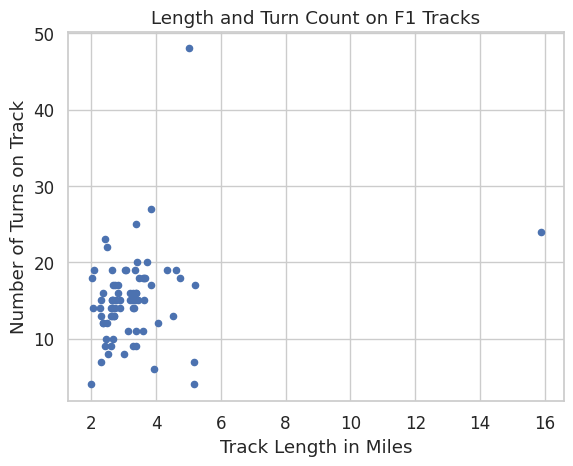

```python
circuits_df.plot.scatter(x='length_in_mi', y='turns', title='Length and Turn Count on F1 Tracks', xlabel='Track Length in Miles', ylabel='Number of Turns on Track')
```

As we can see, two of the tracks seem to be very large outliers. Let's try removing them and see how it affects our summary statistics.

```python
circuits_df = circuits_df[(circuits_df['turns'] < 30) & (circuits_df['length_in_mi'] < 6)]
circuits_df
```

|  | id | name | fullName | previousNames | type | direction | placeName | countryId | latitude | longitude | length_in_km | turns | totalRacesHeld | length_in_mi |
| --- | --- | --- | --- | --- | --- | --- | --- | --- | --- | --- | --- | --- | --- | --- |
| 0 | adelaide | Adelaide | Adelaide Street Circuit | NaN | STREET | CLOCKWISE | Adelaide | australia | -34.927222 | 138.617222 | 3.780 | 16 | 11 | 2.348782 |
| 1 | aida | Aida | Okayama International Circuit | TI Circuit Aida | RACE | CLOCKWISE | Aida | japan | 34.915000 | 134.221111 | 3.703 | 13 | 2 | 2.300937 |
| 2 | ain-diab | Ain-Diab | Ain-Diab Circuit | NaN | ROAD | CLOCKWISE | Casablanca | morocco | 33.578611 | -7.687500 | 7.618 | 18 | 1 | 4.733604 |
| 3 | aintree | Aintree | Aintree Motor Racing Circuit | NaN | ROAD | CLOCKWISE | Aintree | united-kingdom | 53.476944 | -2.940556 | 4.828 | 8 | 5 | 2.999979 |
| 4 | anderstorp | Anderstorp Raceway | Anderstorp Raceway | Scandinavian Raceway | RACE | CLOCKWISE | Anderstorp | sweden | 57.264167 | 13.601389 | 4.031 | 8 | 6 | 2.504747 |
| ... | ... | ... | ... | ... | ... | ... | ... | ... | ... | ... | ... | ... | ... | ... |
| 72 | yas-marina | Yas Marina | Yas Marina Circuit | NaN | RACE | ANTI_CLOCKWISE | Abu Dhabi | united-arab-emirates | 24.467222 | 54.603056 | 5.281 | 16 | 16 | 3.281460 |
| 73 | yeongam | Korea | Korea International Circuit | NaN | RACE | ANTI_CLOCKWISE | Yeongam | south-korea | 34.733333 | 126.416667 | 5.615 | 18 | 4 | 3.488998 |
| 74 | zandvoort | Zandvoort | Circuit Park Zandvoort | NaN | RACE | CLOCKWISE | Zandvoort | netherlands | 52.388819 | 4.540922 | 4.259 | 14 | 34 | 2.646419 |
| 75 | zeltweg | Zeltweg | Zeltweg | NaN | ROAD | CLOCKWISE | Zeltweg | austria | 47.202222 | 14.742222 | 3.186 | 4 | 1 | 1.979688 |
| 76 | zolder | Zolder | Circuit Zolder | NaN | RACE | CLOCKWISE | Heusden-Zolder | belgium | 50.988889 | 5.255556 | 4.262 | 15 | 10 | 2.648283 |

75 rows × 14 columns

```python
circuits_df['turns'].describe()
```

|  | turns |
| --- | --- |
| count | 75.000000 |
| mean | 14.600000 |
| std | 4.420468 |
| min | 4.000000 |
| 25% | 12.000000 |
| 50% | 15.000000 |
| 75% | 17.500000 |
| max | 27.000000 |

**dtype:** float64

```python
circuits_df['length_in_mi'].describe()
```

|  | length_in_mi |
| --- | --- |
| count | 75.000000 |
| mean | 3.115844 |
| std | 0.747151 |
| min | 1.979688 |
| 25% | 2.609448 |
| 50% | 2.999979 |
| 75% | 3.434939 |
| max | 5.194662 |

**dtype:** float64

As we can see, this affected the averages greatly:

1. Average turns went from 15.16 -> 14.6
2. Average length in miles went from 3.31 -> 3.11

These are considerably large changes, especially when they are being made by only 2 out of 77 of our data points!

If we want to make statements about the 'average' F1 track, it is probably more accurate to exclude these two tracks, which are clearly not 'average'.

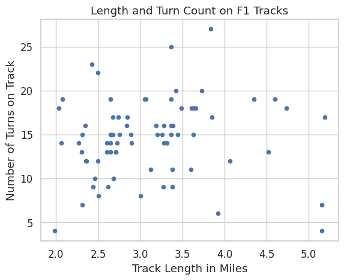

```python
circuits_df.plot.scatter(x='length_in_mi', y='turns', title='Length and Turn Count on F1 Tracks', xlabel='Track Length in Miles', ylabel='Number of Turns on Track')
```

### Hypothesis Test 1

As somewhat of a sanity check, let's do a correlation test to see if the length of the circuit correlates to the circuit taking longer to complete.

**Null Hypothesis**: there is no correlation between track distance and time to complete a track.  
**Alternative Hypothesis**: there is a correlation between track distance and time to complete a track.  
**Significance Value (alpha)**: 0.05

```python
from scipy.stats import pearsonr

# Load race result and race data
results_df = pd.read_csv('drive/MyDrive/CMSC320_Data/f1db-races-race-results.csv', low_memory=False)
races_df = pd.read_csv('drive/MyDrive/CMSC320_Data/f1db-races.csv')

# Filter race results to 2022 and later (this is for consistency, because of 2022 regulation changes)
results_df = results_df[results_df['year'] >= 2022]

# Function to convert H:MM:SS.ms to seconds
def time_to_seconds(time):
    try:
        if len(str(time).split(":")) != 3:
            return None
        h, m, s = str(time).split(":")
        return int(h) * 3600 + int(m) * 60 + float(s)
    except:
        return None

# Apply the conversion
results_df['time_in_seconds'] = results_df['time'].apply(time_to_seconds)
results_df = results_df[results_df['time_in_seconds'].notna()]

# Merge circuit info into results
races_df = races_df.rename(columns={'id': 'raceId'})
results_df = results_df.merge(races_df[['raceId', 'circuitId']], on='raceId', how='left')

# Calculate average total race time per circuit
average_times_by_circuit = results_df.groupby('circuitId')['time_in_seconds'].mean().reset_index()
average_times_by_circuit = average_times_by_circuit.rename(columns={'time_in_seconds': 'average_total_time'})

# Load circuits and merge in average times
circuits_df = pd.read_csv('drive/MyDrive/CMSC320_Data/f1db-circuits.csv')
circuits_df = circuits_df.rename(columns={'id': 'circuitId'})
circuits_df['length_in_mi'] = circuits_df['length'] * 0.621371  # Adding length_in_mi back since DF reloaded here.
circuits_df = circuits_df.merge(average_times_by_circuit, on='circuitId', how='left')

# Drop missing and compute correlation
df = circuits_df[['length_in_mi', 'average_total_time']].dropna()
corr, p_val = pearsonr(df['length_in_mi'], df['average_total_time'])

print(f"Pearson correlation: {corr:.3f}")
print(f"P-value: {p_val:.5f}")
```

```
Pearson correlation: -0.417
P-value: 0.03803
```

### Interpretation of Hypothesis Test 1

Now for fun: let's visualize that correlation!

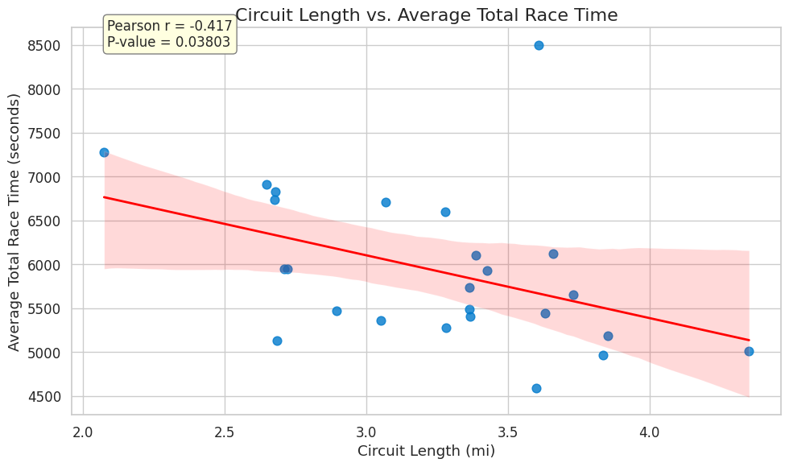

```python
sea.set(style='whitegrid', font_scale=1.1)

plt.figure(figsize=(10, 6))
sea.regplot(
    data=df,
    x='length_in_mi',
    y='average_total_time',
    scatter_kws={'s': 60, 'color': '#007acc'}, #
    line_kws={'color': 'red', 'linewidth': 2}
)

plt.title('Circuit Length vs. Average Total Race Time', fontsize=16)
plt.xlabel('Circuit Length (mi)')
plt.ylabel('Average Total Race Time (seconds)')
plt.text(
    0.05, 0.95,
    f'Pearson r = {corr:.3f}\nP-value = {p_val:.5f}',
    transform=plt.gca().transAxes,
    fontsize=12,
    bbox=dict(boxstyle="round,pad=0.3", edgecolor='gray', facecolor='lightyellow')
)

plt.tight_layout()
plt.show()
```

### Hypothesis Test 2

I have a few other hypotheses. Let's start with this one: Does the frequency of races held on a track effect laptime?

**Null Hypothesis**: There is no correlation between frequency of races held and lap time.  
**Alternative Hypothesis**: There is a correlation between frequency of races held and lap time.

```python
df = circuits_df[['totalRacesHeld', 'average_total_time']].dropna()
corr, p_val = pearsonr(df['totalRacesHeld'], df['average_total_time'])
print(f"Pearson correlation between races held and lap times: {corr:.3f}")
print(f"P-value: {p_val:.5f}")
```

```
Pearson correlation between races held and lap times: 0.152
P-value: 0.46890
```

### Interpretation of Hypothesis Test #2

Since our P-value is 0.47, which is greater than 0.05, we can say with confidence that there is not a statistically significant correlation between these two variables, and accept the Null Hypothesis!

And let's graph this one as well...

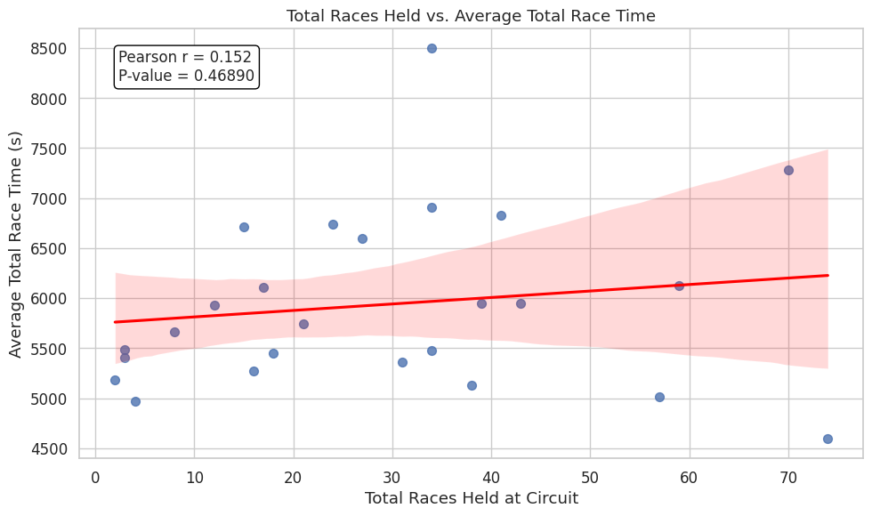

```python
average_times_by_circuit = results_df.groupby('circuitId')['time_in_seconds'].mean().reset_index()
average_times_by_circuit = average_times_by_circuit.rename(columns={'time_in_seconds': 'average_total_time'})


circuits_df = circuits_df.merge(average_times_by_circuit, on='circuitId', how='left')


cleaned_df = circuits_df[['totalRacesHeld', 'average_total_time']].dropna()


plt.figure(figsize=(10, 6))
sea.regplot(data=cleaned_df, x='totalRacesHeld', y='average_total_time', scatter_kws={'s': 50}, line_kws={'color': 'red'})
plt.title('Total Races Held vs. Average Total Race Time')
plt.xlabel('Total Races Held at Circuit')
plt.ylabel('Average Total Race Time (s)')


corr, p_val = pearsonr(df['totalRacesHeld'], df['average_total_time'])
plt.text(0.05, 0.95,
         f"Pearson r = {corr:.3f}\nP-value = {p_val:.5f}",
         transform=plt.gca().transAxes,
         fontsize=12,
         verticalalignment='top',
         bbox=dict(boxstyle="round,pad=0.3", edgecolor="black", facecolor="white"))

plt.grid(True)
plt.tight_layout()
plt.show()
```

## Feature Engineering

Let's continue by removing the unnecessary features for our model.

```python
# Remove unnecessary features
circuits_df = circuits_df[['circuitId', 'type', 'length_in_mi', 'turns']]
circuits_df
```

|  | circuitId | type | length_in_mi | turns |
| --- | --- | --- | --- | --- |
| 0 | adelaide | STREET | 2.348782 | 16 |
| 1 | aida | RACE | 2.300937 | 13 |
| 2 | ain-diab | ROAD | 4.733604 | 18 |
| 3 | aintree | ROAD | 2.999979 | 8 |
| 4 | anderstorp | RACE | 2.504747 | 8 |
| ... | ... | ... | ... | ... |
| 72 | yas-marina | RACE | 3.281460 | 16 |
| 73 | yeongam | RACE | 3.488998 | 18 |
| 74 | zandvoort | RACE | 2.646419 | 14 |
| 75 | zeltweg | ROAD | 1.979688 | 4 |
| 76 | zolder | RACE | 2.648283 | 15 |

77 rows × 4 columns

Now let's engineer a new feature: turn_density. This represents number of turns per mile of a track.

```python
circuits_df['turn_density'] = circuits_df['turns'] / circuits_df['length_in_mi']
circuits_df
```

|  | circuitId | type | length_in_mi | turns | turn_density |
| --- | --- | --- | --- | --- | --- |
| 0 | adelaide | STREET | 2.348782 | 16 | 6.812040 |
| 1 | aida | RACE | 2.300937 | 13 | 5.649873 |
| 2 | ain-diab | ROAD | 4.733604 | 18 | 3.802599 |
| 3 | aintree | ROAD | 2.999979 | 8 | 2.666685 |
| 4 | anderstorp | RACE | 2.504747 | 8 | 3.193936 |
| ... | ... | ... | ... | ... | ... |
| 72 | yas-marina | RACE | 3.281460 | 16 | 4.875878 |
| 73 | yeongam | RACE | 3.488998 | 18 | 5.159074 |
| 74 | zandvoort | RACE | 2.646419 | 14 | 5.290167 |
| 75 | zeltweg | ROAD | 1.979688 | 4 | 2.020520 |
| 76 | zolder | RACE | 2.648283 | 15 | 5.664047 |

77 rows × 5 columns

Finally, let's engineer one more very important feature: the average time it takes for drivers to complete the track.

The first step for this will be getting the race data. We are going to filter out any race data from before 2022, since there was a major regulation change around this time that might largely affect the time it takes for drivers to complete a track.

```python
# Get all race results
results_df = pd.read_csv('drive/MyDrive/CMSC320_Data/f1db-races-race-results.csv')

# Filter out race results from before 2022
results_df = results_df[results_df['year'] >= 2022]

# For each race result, convert H:MM:SS.mm to just number of seconds
def time_to_seconds(time):
  try:
    if(len(time.split(":")) != 3): # ignore incorrectly formatted times
      return None
    h, m, s = time.split(":")
    return int(h) * 3600 + int(m) * 60 + float(s)
  except:
    return None

results_df['time_in_seconds'] = results_df['time'].apply(time_to_seconds)

# For each race result, get the circuit it was on from the races df
races_df = pd.read_csv('drive/MyDrive/CMSC320_Data/f1db-races.csv')
races_df = races_df.rename(columns={'id': 'raceId'}) # need to rename to match
results_df = results_df.merge(races_df[['raceId', 'circuitId']], on='raceId', how='left')

# Drop columns where time is NaN
results_df = results_df[results_df['time_in_seconds'].notna()]

# Convert time_in_seconds to be per lap
results_df['time_in_seconds'] = results_df['time_in_seconds'] / results_df['laps']

# Group race results by circuit
average_times_by_circuit = results_df.groupby(results_df['circuitId'])['time_in_seconds'].mean().reset_index()
average_times_by_circuit = average_times_by_circuit.rename(columns={'time_in_seconds': 'average_seconds_per_lap'})

# Merge average times into circuits_df
circuits_df = circuits_df.rename(columns={'id': 'circuitId'})
circuits_df = average_times_by_circuit.merge(circuits_df, on='circuitId', how='left')

# Note: The above also removes most of the circuits from the circuitsdf, because most circuits are historical
# and don't have any race data from 2022 or later.

circuits_df
```

|  | circuitId | average_seconds_per_lap | type | length_in_mi | turns | turn_density |
| --- | --- | --- | --- | --- | --- | --- |
| 0 | austin | 105.901744 | RACE | 3.425618 | 20 | 5.838362 |
| 1 | bahrain | 100.701034 | RACE | 3.362860 | 15 | 4.460489 |
| 2 | baku | 110.943023 | STREET | 3.730090 | 20 | 5.361801 |
| 3 | catalunya | 82.970834 | RACE | 2.893725 | 14 | 4.838055 |
| 4 | hungaroring | 84.937938 | RACE | 2.722226 | 14 | 5.142849 |
| 5 | imola | 85.133344 | RACE | 3.050310 | 19 | 6.228875 |
| 6 | interlagos | 97.378447 | RACE | 2.677488 | 15 | 5.602267 |
| 7 | jeddah | 99.353245 | STREET | 3.836345 | 27 | 7.037950 |
| 8 | las-vegas | 103.667841 | STREET | 3.853122 | 17 | 4.412007 |
| 9 | lusail | 94.841690 | RACE | 3.367209 | 16 | 4.751709 |
| 10 | marina-bay | 110.340451 | STREET | 3.069573 | 19 | 6.189787 |
| 11 | melbourne | 113.750937 | STREET | 3.279596 | 14 | 4.268818 |
| 12 | mexico-city | 94.932719 | RACE | 2.674381 | 17 | 6.356612 |
| 13 | miami | 96.250501 | STREET | 3.362860 | 19 | 5.649953 |
| 14 | monaco | 102.860851 | STREET | 2.073515 | 19 | 9.163184 |
| 15 | montreal | 84.946750 | STREET | 2.709799 | 13 | 4.797404 |
| 16 | monza | 87.949576 | RACE | 3.599602 | 11 | 3.055893 |
| 17 | paul-ricard | 102.811693 | RACE | 3.630049 | 15 | 4.132175 |
| 18 | shanghai | 109.007788 | RACE | 3.387093 | 16 | 4.723814 |
| 19 | silverstone | 117.745545 | RACE | 3.660497 | 18 | 4.917366 |
| 20 | spa-francorchamps | 113.978345 | RACE | 4.352082 | 19 | 4.365726 |
| 21 | spielberg | 72.245309 | RACE | 2.683080 | 10 | 3.727060 |
| 22 | suzuka | 250.244388 | RACE | 3.608301 | 18 | 4.988497 |
| 23 | yas-marina | 90.957509 | RACE | 3.281460 | 16 | 4.875878 |
| 24 | zandvoort | 95.937959 | RACE | 2.646419 | 14 | 5.290167 |

Next: convert our categorical 'type' variable to numerical data using One Hot Encoding. This will be important for performing regression.

```python
from sklearn.preprocessing import OneHotEncoder

circuits_encoded = pd.get_dummies(circuits_df, columns=['type'])
circuits_encoded
```

|  | circuitId | average_seconds_per_lap | length_in_mi | turns | turn_density | type_RACE | type_STREET |
| --- | --- | --- | --- | --- | --- | --- | --- |
| 0 | austin | 105.901744 | 3.425618 | 20 | 5.838362 | True | False |
| 1 | bahrain | 100.701034 | 3.362860 | 15 | 4.460489 | True | False |
| 2 | baku | 110.943023 | 3.730090 | 20 | 5.361801 | False | True |
| 3 | catalunya | 82.970834 | 2.893725 | 14 | 4.838055 | True | False |
| 4 | hungaroring | 84.937938 | 2.722226 | 14 | 5.142849 | True | False |
| 5 | imola | 85.133344 | 3.050310 | 19 | 6.228875 | True | False |
| 6 | interlagos | 97.378447 | 2.677488 | 15 | 5.602267 | True | False |
| 7 | jeddah | 99.353245 | 3.836345 | 27 | 7.037950 | False | True |
| 8 | las-vegas | 103.667841 | 3.853122 | 17 | 4.412007 | False | True |
| 9 | lusail | 94.841690 | 3.367209 | 16 | 4.751709 | True | False |
| 10 | marina-bay | 110.340451 | 3.069573 | 19 | 6.189787 | False | True |
| 11 | melbourne | 113.750937 | 3.279596 | 14 | 4.268818 | False | True |
| 12 | mexico-city | 94.932719 | 2.674381 | 17 | 6.356612 | True | False |
| 13 | miami | 96.250501 | 3.362860 | 19 | 5.649953 | False | True |
| 14 | monaco | 102.860851 | 2.073515 | 19 | 9.163184 | False | True |
| 15 | montreal | 84.946750 | 2.709799 | 13 | 4.797404 | False | True |
| 16 | monza | 87.949576 | 3.599602 | 11 | 3.055893 | True | False |
| 17 | paul-ricard | 102.811693 | 3.630049 | 15 | 4.132175 | True | False |
| 18 | shanghai | 109.007788 | 3.387093 | 16 | 4.723814 | True | False |
| 19 | silverstone | 117.745545 | 3.660497 | 18 | 4.917366 | True | False |
| 20 | spa-francorchamps | 113.978345 | 4.352082 | 19 | 4.365726 | True | False |
| 21 | spielberg | 72.245309 | 2.683080 | 10 | 3.727060 | True | False |
| 22 | suzuka | 250.244388 | 3.608301 | 18 | 4.988497 | True | False |
| 23 | yas-marina | 90.957509 | 3.281460 | 16 | 4.875878 | True | False |
| 24 | zandvoort | 95.937959 | 2.646419 | 14 | 5.290167 | True | False |

## Primary Analysis

Our model's goal: use type, length_in_mi, turns, and turn_density in order to predict average_seconds_per_lap. This could be used when creating future F1 circuits, to predict how long they might take to complete.

In order to predict how long it takes to complete a circuit as a number of average seconds per lap, we know that we will have to use regression, since we are working with continuous data. We don't think clustering would be the best fit, since we don't ultimately want to categorize the circuits.

Step one: set up our training data

```python
# Drop average_seconds_per_lap from training because it's what we want to predict
X = pd.DataFrame(circuits_encoded.drop(['average_seconds_per_lap', 'circuitId'], axis=1))

# Set average_seconds_per_lap as our target to predict
y = circuits_encoded['average_seconds_per_lap']
```

Step two: utilize LOOCV with several different models to predict average_seconds_per_lap

```python
import numpy as np
from sklearn.model_selection import LeaveOneOut
from sklearn.metrics import mean_squared_error

# models to import
from sklearn.linear_model import LinearRegression
from sklearn.ensemble import RandomForestRegressor
from sklearn.tree import DecisionTreeRegressor
from sklearn.neighbors import KNeighborsRegressor

loo = LeaveOneOut()
models = {
  'LinearRegression': LinearRegression(),
  'RandomForest': RandomForestRegressor(),
  'DecisionTree': DecisionTreeRegressor(),
  'KNeighbors': KNeighborsRegressor(),
}

errors = [] # tracks total error

for model_name, model in models.items():
  for train, test in loo.split(X):
    X_train, X_test = X.iloc[train], X.iloc[test]
    y_train, y_test = y.iloc[train], y.iloc[test]

    model.fit(X_train, y_train)
    y_pred = model.predict(X_test)

    error = (y_pred[0] - y_test.values[0]) ** 2
    errors.append(error)

  # Calculate RMSE
  rmse = np.sqrt(np.mean(errors))
  errors = [] # reset error for next iteration
  print(f"{model_name} RMSE: {rmse} seconds")
```

```
LinearRegression RMSE: 33.95887933080941 seconds
RandomForest RMSE: 38.489605682293046 seconds
DecisionTree RMSE: 53.28578547903562 seconds
KNeighbors RMSE: 34.687788599444346 seconds
```

Okay we've successfully done some machine learning, but our error is quite high. Let's try some strategies to improve this:

Strategy 1: Using StandardScaler

```python
from sklearn.preprocessing import StandardScaler
errors = [] # tracks total error

for model_name, model in models.items():
  for train, test in loo.split(X):
    scaler = StandardScaler()
    X_train = X.iloc[train]
    X_test = X.iloc[test]
    X_train_scaled = scaler.fit_transform(X_train)
    X_test_scaled = scaler.transform(X_test) # don't fit so model doesn't see test data

    y_train, y_test = y.iloc[train], y.iloc[test]

    model.fit(X_train_scaled, y_train)
    y_pred = model.predict(X_test_scaled)

    error = (y_pred[0] - y_test.values[0]) ** 2
    errors.append(error)

  # Calculate RMSE
  rmse = np.sqrt(np.mean(errors))
  errors = [] # reset error for next iteration
  print(f"{model_name} RMSE: {rmse} seconds")
```

```
LinearRegression RMSE: 33.958879330809424 seconds
RandomForest RMSE: 42.894249481268744 seconds
DecisionTree RMSE: 53.3786247132206 seconds
KNeighbors RMSE: 34.36872175236407 seconds
```

Wow, so that basically made no difference. Next, let's try polynomial feature expansion on degree 2.

Strategy 2: 2 Degree Polynomial Feature Expansion

```python
from sklearn.preprocessing import PolynomialFeatures

poly = PolynomialFeatures(degree=2, include_bias=False)
X_poly = poly.fit_transform(X)
X_poly_df = pd.DataFrame(X_poly, columns=poly.get_feature_names_out(X.columns), index=X.index)

errors = []

for model_name, model in models.items():
    for train_index, test_index in loo.split(X_poly_df):
        # Split the *polynomial* feature matrix
        X_train_poly = X_poly_df.iloc[train_index]
        X_test_poly = X_poly_df.iloc[test_index]
        y_train, y_test = y.iloc[train_index], y.iloc[test_index]

        model.fit(X_train_poly, y_train)
        y_pred = model.predict(X_test_poly)

        error = (y_pred[0] - y_test.values[0]) ** 2
        errors.append(error)

    rmse = np.sqrt(np.mean(errors))
    errors = []
    print(f"{model_name} RMSE with poly features: {rmse:.2f} seconds")
```

```
LinearRegression RMSE with poly features: 62.50 seconds
RandomForest RMSE with poly features: 38.38 seconds
DecisionTree RMSE with poly features: 52.77 seconds
KNeighbors RMSE with poly features: 33.99 seconds
```

As we can see, this improved our results a bit for some models, but still not by a lot. As another test, let's try various models but with KFold instead.

```python
import numpy as np
import pandas as pd

from sklearn.linear_model import LinearRegression
from sklearn.ensemble import RandomForestRegressor
from sklearn.tree import DecisionTreeRegressor
from sklearn.neighbors import KNeighborsRegressor
from sklearn.model_selection import KFold
from sklearn.preprocessing import StandardScaler
from sklearn.metrics import mean_squared_error

kfold = KFold(n_splits=5, shuffle=True, random_state=42)
models = {
  'LinearRegression': LinearRegression(),
  'RandomForest': RandomForestRegressor(),
  'DecisionTree': DecisionTreeRegressor(),
  'KNeighbors': KNeighborsRegressor(),
}

for model_name, model in models.items():
    errors = []
    for train_idx, test_idx in kfold.split(X):
        scaler = StandardScaler()
        X_train, X_test = X.iloc[train_idx], X.iloc[test_idx]
        y_train, y_test = y.iloc[train_idx], y.iloc[test_idx]

        X_train_scaled = scaler.fit_transform(X_train)
        X_test_scaled = scaler.transform(X_test)

        model.fit(X_train_scaled, y_train)
        y_pred = model.predict(X_test_scaled)
        errors.extend((y_pred - y_test) ** 2)

    rmse = np.sqrt(np.mean(errors))
    print(f"{model_name} K-Fold RMSE: {rmse:.2f} seconds")
```

```
LinearRegression K-Fold RMSE: 40.94 seconds
RandomForest K-Fold RMSE: 39.84 seconds
DecisionTree K-Fold RMSE: 53.18 seconds
KNeighbors K-Fold RMSE: 33.00 seconds
```

## Interpretation

Looks like KNeighbors is the most consistent model across LOOCV and KFolds. In that case, we should give it a try after we do some feature engineering to reduce our numbers a bit more.

First off: let's do some cleaning. The best model we have currently isn't doing great, so let's try to handle outliers in the race times before we calculate our average lap time to hopefully remove any false correlations in the data.

Let's start by plotting all of the race times to see if there are any outliers:

[figure not shown]

```python
# Group by circuitId
circuit_times = results_df.groupby('circuitId')

# Plot each circuit's times
for circuit_id, group in circuit_times:
    # Plot the individual times
    plt.plot(group['time_in_seconds'].values, label=f'Circuit {circuit_id}')

plt.xlabel('Race Instance')
plt.ylabel('Time In Seconds')
plt.legend(bbox_to_anchor=(1, 1))
plt.title('Race Times by Circuit')
plt.grid(True)
plt.show()
```

As we can see, several circuits have major outliers, which could be hurting the accuracy of our model. Let's investigate some of these deeper:

```python
# Look at suzuka, since this has two chunks of races with wildly different times
suzuka_df = results_df[results_df['circuitId'] == 'suzuka']
suzuka_df[['time', 'time_in_seconds', 'laps']]

races_df[races_df['raceId'] == 1075]
```

|  | raceId | year | round | date | time | grandPrixId | officialName | qualifyingFormat | sprintQualifyingFormat | circuitId | ... | qualifying2Date | qualifying2Time | qualifyingDate | qualifyingTime | sprintQualifyingDate | sprintQualifyingTime | sprintRaceDate | sprintRaceTime | warmingUpDate | warmingUpTime |
| --- | --- | --- | --- | --- | --- | --- | --- | --- | --- | --- | --- | --- | --- | --- | --- | --- | --- | --- | --- | --- | --- |
| 1074 | 1075 | 2022 | 18 | 2022-10-09 | NaN | japan | Formula 1 Honda Japanese Grand Prix 2022 | KNOCKOUT | NaN | suzuka | ... | NaN | NaN | NaN | NaN | NaN | NaN | NaN | NaN | NaN | NaN |

1 rows × 42 columns

For some reason, half of the suzuka races seem to have taken nearly 3 hours, which is absurdly long. After further investigation, this seems to be due to a rain delay in race #1075, round 18 of the 2022 F1 season. This rain delay also came with the race being shortened from 53 to 28 laps. Let's try to filter out any races that were shortened.

```python
rain_race = races_df[races_df['raceId'] == 1075]
reg_race = races_df[races_df['raceId'] == 1095]

display(rain_race[['laps', 'scheduledLaps']])
display(reg_race[['laps', 'scheduledLaps']])
```

|  | laps | scheduledLaps |
| --- | --- | --- |
| 1074 | 28 | 53.0 |

|  | laps | scheduledLaps |
| --- | --- | --- |
| 1094 | 53 | NaN |

As we can see from the above code segment, scheduledLaps is only not NA for races where not all scheduled laps were completed. As such, we can filter these out by getting all of the races where scheduledLaps is not NA and removing them from our results.

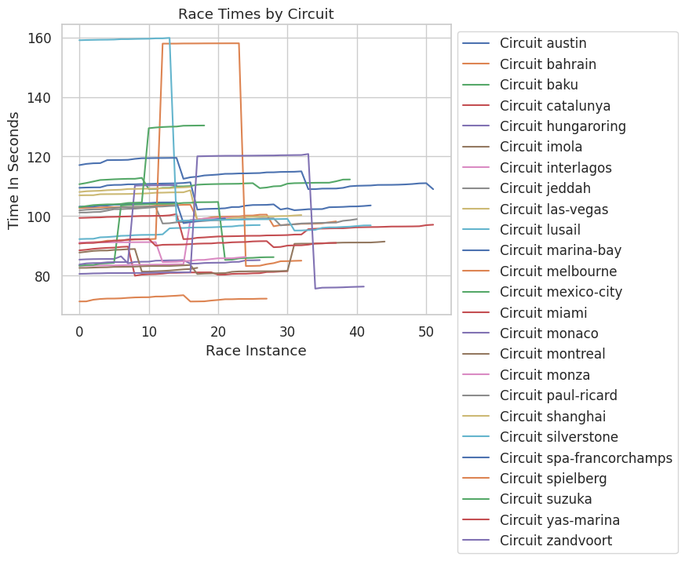

```python
races_to_remove = races_df[races_df['scheduledLaps'].notna()]
race_ids_to_remove = races_to_remove['raceId']

filtered_results = results_df[~results_df['raceId'].isin(race_ids_to_remove)]

# Group by circuitId
circuit_times = filtered_results.groupby('circuitId')

# Plot each circuit's times
for circuit_id, group in circuit_times:
    # Plot the individual times
    plt.plot(group['time_in_seconds'].values, label=f'Circuit {circuit_id}')

plt.xlabel('Race Instance')
plt.ylabel('Time In Seconds')
plt.legend(bbox_to_anchor=(1, 1))
plt.title('Race Times by Circuit')
plt.grid(True)
plt.show()
```

This definitely removed *some* discrepancies, but unfortunately there are clearly still periods of randomly higher and lower times for certain circuits. Let's investigate further.

```python
silverstone_df = results_df[results_df['circuitId'] == 'silverstone']
silverstone_df[['raceId', 'time_in_seconds', 'time']]
```

|  | raceId | time_in_seconds | time |
| --- | --- | --- | --- |
| 180 | 1067 | 159.044442 | 2:17:50.311 |
| 181 | 1067 | 159.117115 | 2:17:54.090 |
| 182 | 1067 | 159.164154 | 2:17:56.536 |
| 183 | 1067 | 159.208788 | 2:17:58.857 |
| 184 | 1067 | 159.228500 | 2:17:59.882 |
| 185 | 1067 | 159.274115 | 2:18:02.254 |
| 186 | 1067 | 159.405538 | 2:18:09.088 |
| 187 | 1067 | 159.409731 | 2:18:09.306 |
| 188 | 1067 | 159.474365 | 2:18:12.667 |
| 189 | 1067 | 159.517327 | 2:18:14.901 |
| 190 | 1067 | 159.547269 | 2:18:16.458 |
| 191 | 1067 | 159.669654 | 2:18:22.822 |
| 192 | 1067 | 159.675538 | 2:18:23.128 |
| 193 | 1067 | 159.831173 | 2:18:31.221 |
| 620 | 1089 | 98.402654 | 1:25:16.938 |
| 621 | 1089 | 98.475692 | 1:25:20.736 |
| 622 | 1089 | 98.533096 | 1:25:23.721 |
| 623 | 1089 | 98.552192 | 1:25:24.714 |
| 624 | 1089 | 98.618154 | 1:25:28.144 |
| 625 | 1089 | 98.650385 | 1:25:29.820 |
| 626 | 1089 | 98.733288 | 1:25:34.131 |
| 627 | 1089 | 98.746462 | 1:25:34.816 |
| 628 | 1089 | 98.762058 | 1:25:35.627 |
| 629 | 1089 | 98.776654 | 1:25:36.386 |
| 630 | 1089 | 98.857115 | 1:25:40.570 |
| 631 | 1089 | 98.899385 | 1:25:42.768 |
| 632 | 1089 | 98.915404 | 1:25:43.601 |
| 633 | 1089 | 98.931173 | 1:25:44.421 |
| 634 | 1089 | 98.976115 | 1:25:46.758 |
| 635 | 1089 | 99.003135 | 1:25:48.163 |
| 636 | 1089 | 99.039731 | 1:25:50.066 |
| 1099 | 1113 | 95.135750 | 1:22:27.059 |
| 1100 | 1113 | 95.163923 | 1:22:28.524 |
| 1101 | 1113 | 95.280885 | 1:22:34.606 |
| 1102 | 1113 | 95.374769 | 1:22:39.488 |
| 1103 | 1113 | 96.045712 | 1:23:14.377 |
| 1104 | 1113 | 96.207327 | 1:23:22.781 |
| 1105 | 1113 | 96.223615 | 1:23:23.628 |
| 1106 | 1113 | 96.358385 | 1:23:30.636 |
| 1107 | 1113 | 96.450885 | 1:23:35.446 |
| 1108 | 1113 | 96.660808 | 1:23:46.362 |
| 1109 | 1113 | 96.846519 | 1:23:56.019 |
| 1110 | 1113 | 96.869462 | 1:23:57.212 |

After further research into these two races, it seems there was a red flag, delaying the race by about 45 minutes. We need to find a way to eliminate these situations, but there is no data in our database about when red flags occur.

Luckily, there aren't too many races we have to go through, and a wikipedia article has a list of every race that has been red-flagged (which includes the ones we've removed so far), so let's just remove them manually!

Unluckily, this chart doesn't have the raceIds, so this is gonna be a pretty manual process.

https://en.wikipedia.org/wiki/List_of_red-flagged_Formula_One_races

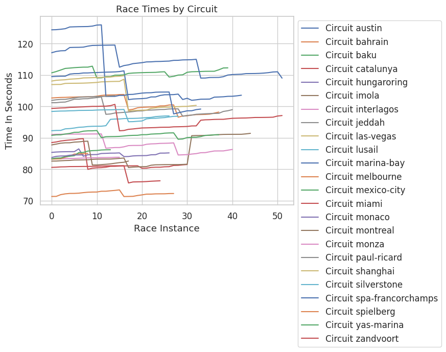

```python
# race ids found by combing through the data
monaco22 = 1064
british22 = 1067
japanese22 = 1075
australian22 = 1060
australian23 = 1082 # this was NOT in the list, but this race was restarted due to multiple false starts
dutch23 = 1092
mexicocity23 = 1098
saopaulo23 = 1099
japanese23 = 1095
monaco24 = 1109
japanese24 = 1105
saopaulo24 = 1122

race_ids_to_remove = [monaco22, british22, japanese22, australian22, australian23, dutch23, mexicocity23, saopaulo23, japanese23, monaco24, saopaulo24, japanese24]

filtered_results = results_df[~results_df['raceId'].isin(race_ids_to_remove)]

# Group by circuitId
circuit_times = filtered_results.groupby('circuitId')

# Plot each circuit's times
for circuit_id, group in circuit_times:
    # Plot the individual times
    plt.plot(group['time_in_seconds'].values, label=f'Circuit {circuit_id}')

plt.xlabel('Race Instance')
plt.ylabel('Time In Seconds')
plt.legend(bbox_to_anchor=(1, 1))
plt.title('Race Times by Circuit')
plt.grid(True)
plt.show()
```

Finally, our race times are looking pretty consistent. There are still some jumps, but this is to be expected since race day conditions, minor regulation changes, or other unforeseen factors will cause some races to just be faster. Unfortunately, there's no way to completely handle these factors without sacrificing most of our data, and this will probably hurt our model's results a little no matter what.

Let's redo our analysis after removing these races. First we'll make sure we have all the appropriate data again:

```python
# Change results_df to be our FILTERED results
results_df = filtered_results

# Remove current average times from circuits_df, as we will recalculate
circuits_df = circuits_df.drop('average_seconds_per_lap', axis=1)

# Group race results by circuit
average_times_by_circuit = results_df.groupby(results_df['circuitId'])['time_in_seconds'].mean().reset_index()
average_times_by_circuit = average_times_by_circuit.rename(columns={'time_in_seconds': 'average_seconds_per_lap'})

# Merge average times into circuits_df
circuits_df = circuits_df.rename(columns={'id': 'circuitId'})
circuits_df = average_times_by_circuit.merge(circuits_df, on='circuitId', how='left')

# Re-do One Hot Encoding
circuits_encoded = pd.get_dummies(circuits_df, columns=['type'])
circuits_encoded
```

|  | circuitId | average_seconds_per_lap | length_in_mi | turns | turn_density | type_RACE | type_STREET |
| --- | --- | --- | --- | --- | --- | --- | --- |
| 0 | austin | 105.901744 | 3.425618 | 20 | 5.838362 | True | False |
| 1 | bahrain | 100.701034 | 3.362860 | 15 | 4.460489 | True | False |
| 2 | baku | 110.943023 | 3.730090 | 20 | 5.361801 | False | True |
| 3 | catalunya | 82.970834 | 2.893725 | 14 | 4.838055 | True | False |
| 4 | hungaroring | 84.937938 | 2.722226 | 14 | 5.142849 | True | False |
| 5 | imola | 85.133344 | 3.050310 | 19 | 6.228875 | True | False |
| 6 | interlagos | 83.562979 | 2.677488 | 15 | 5.602267 | True | False |
| 7 | jeddah | 99.353245 | 3.836345 | 27 | 7.037950 | False | True |
| 8 | las-vegas | 103.667841 | 3.853122 | 17 | 4.412007 | False | True |
| 9 | lusail | 94.841690 | 3.367209 | 16 | 4.751709 | True | False |
| 10 | marina-bay | 110.340451 | 3.069573 | 19 | 6.189787 | False | True |
| 11 | melbourne | 84.169165 | 3.279596 | 14 | 4.268818 | False | True |
| 12 | mexico-city | 84.986842 | 2.674381 | 17 | 6.356612 | True | False |
| 13 | miami | 96.250501 | 3.362860 | 19 | 5.649953 | False | True |
| 14 | monaco | 84.300865 | 2.073515 | 19 | 9.163184 | False | True |
| 15 | montreal | 84.946750 | 2.709799 | 13 | 4.797404 | False | True |
| 16 | monza | 87.949576 | 3.599602 | 11 | 3.055893 | True | False |
| 17 | paul-ricard | 102.811693 | 3.630049 | 15 | 4.132175 | True | False |
| 18 | shanghai | 109.007788 | 3.387093 | 16 | 4.723814 | True | False |
| 19 | silverstone | 97.637611 | 3.660497 | 18 | 4.917366 | True | False |
| 20 | spa-francorchamps | 113.978345 | 4.352082 | 19 | 4.365726 | True | False |
| 21 | spielberg | 72.245309 | 2.683080 | 10 | 3.727060 | True | False |
| 22 | yas-marina | 90.957509 | 3.281460 | 16 | 4.875878 | True | False |
| 23 | zandvoort | 79.355528 | 2.646419 | 14 | 5.290167 | True | False |

And now let's test some models using LOOCV once again:

```python
# Drop average_seconds_per_lap from training because it's what we want to predict
X = pd.DataFrame(circuits_encoded.drop(['average_seconds_per_lap', 'circuitId'], axis=1))

# Set average_seconds_per_lap as our target to predict
y = circuits_encoded['average_seconds_per_lap']

import numpy as np
import pandas as pd

from sklearn.linear_model import LinearRegression
from sklearn.ensemble import RandomForestRegressor
from sklearn.tree import DecisionTreeRegressor
from sklearn.neighbors import KNeighborsRegressor
from sklearn.model_selection import LeaveOneOut
from sklearn.metrics import mean_squared_error
from math import sqrt

loo = LeaveOneOut()
models = {
  'LinearRegression': LinearRegression(),
  'RandomForest': RandomForestRegressor(),
  'DecisionTree': DecisionTreeRegressor(),
  'KNeighbors': KNeighborsRegressor(),
}

predictions = []
actuals = []

for model_name, model in models.items():
    actuals = []
    predictions = []
    errors = []

    for train_idx, test_idx in loo.split(X):
        X_train, X_test = X.iloc[train_idx], X.iloc[test_idx]
        y_train, y_test = y.iloc[train_idx], y.iloc[test_idx]

        model.fit(X_train, y_train)
        y_pred = model.predict(X_test)

        actuals.append(y_test.values[0])
        predictions.append(y_pred[0])
        errors.append((y_pred[0] - y_test.values[0]) ** 2)

    rmse = sqrt(sum(errors) / len(errors))
    print(f"{model_name} LOOCV RMSE: {rmse:.2f} seconds")

    # Actual vs predicted of first 5 circuits for each model
    circuit_errors = pd.DataFrame({
        'Circuit': circuits_encoded.loc[X.index, 'circuitId'],
        'Actual':   actuals,
        'Predicted':predictions
    })
    print(circuit_errors.head(), "\n")
```

```
LinearRegression LOOCV RMSE: 10.07 seconds
       Circuit      Actual   Predicted
0       austin  105.901744   97.858233
1      bahrain  100.701034   93.525752
2         baku  110.943023  103.468793
3    catalunya   82.970834   85.635911
4  hungaroring   84.937938   82.612455

RandomForest LOOCV RMSE: 9.33 seconds
       Circuit      Actual   Predicted
0       austin  105.901744   99.909334
1      bahrain  100.701034   96.935631
2         baku  110.943023  100.266811
3    catalunya   82.970834   85.454950
4  hungaroring   84.937938   82.624056

DecisionTree LOOCV RMSE: 10.86 seconds
       Circuit      Actual   Predicted
0       austin  105.901744  109.007788
1      bahrain  100.701034   94.841690
2         baku  110.943023   97.637611
3    catalunya   82.970834   84.937938
4  hungaroring   84.937938   82.970834

KNeighbors LOOCV RMSE: 8.37 seconds
       Circuit      Actual   Predicted
0       austin  105.901744  103.329133
1      bahrain  100.701034   96.117903
2         baku  110.943023  102.320877
3    catalunya   82.970834   90.273834
4  hungaroring   84.937938   89.880414
```

Hooray, our results are much better! I included all of the models here to show that KNeighbors LOOCV is still the best method for accuracy of predictions. This table also helps us visualize some of the race time predictions and actual times. Although we did have good results with KFolds earlier, we only have 24 circuits, and we know that LOOCV should be theoretically better for small datasets.

Next, Let's see if there are any big prectiction outliers. We can visualize this on a bar chart to see if there are any massive differences, and if we need to trim any more circuits from the dataset.

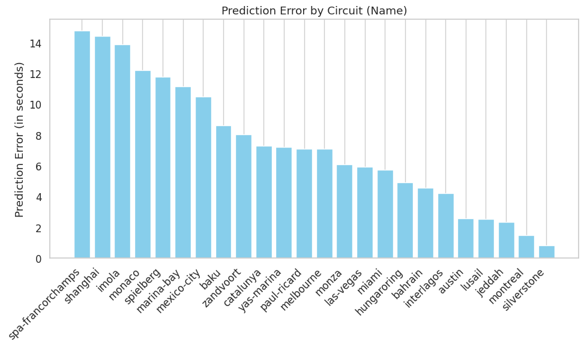

```python
# Add an Error column to the pd
circuit_errors['Error'] = abs(circuit_errors['Predicted'] - circuit_errors['Actual'])

# Sort by largest error
circuit_errors_sorted = circuit_errors.sort_values(by='Error', ascending=False)

import matplotlib.pyplot as plt

plt.figure(figsize=(10, 6))
plt.bar(circuit_errors_sorted['Circuit'], circuit_errors_sorted['Error'], color='skyblue')
plt.xticks(rotation=45, ha='right')
plt.ylabel("Prediction Error (in seconds)")
plt.title("Prediction Error by Circuit (Name)")
plt.grid(axis='y')
plt.tight_layout()
plt.show()
```

Analysis: There isn't a huge difference in error in predicting any of these circuits, so it looks like we don't have any extreme outliers.

We're almost there, but there is one more step we want to take: tuning our KNeighbors hyperparameters. Since this was the best model, we're hoping we can tweak it to be even better.

```python
# Drop average_seconds_per_lap from training because it's what we want to predict
X = pd.DataFrame(circuits_encoded.drop(['average_seconds_per_lap', 'circuitId'], axis=1))

# Set average_seconds_per_lap as our target to predict
y = circuits_encoded['average_seconds_per_lap']

import numpy as np
import pandas as pd

from sklearn.neighbors import KNeighborsRegressor
from sklearn.model_selection import LeaveOneOut
from sklearn.metrics import mean_squared_error
from math import sqrt

loo = LeaveOneOut()
model = KNeighborsRegressor(n_neighbors = 5, weights='uniform')

actuals = []
predictions = []
errors = []

for train_idx, test_idx in loo.split(X):
    X_train, X_test = X.iloc[train_idx], X.iloc[test_idx]
    y_train, y_test = y.iloc[train_idx], y.iloc[test_idx]

    model.fit(X_train, y_train)
    y_pred = model.predict(X_test)

    actuals.append(y_test.values[0])
    predictions.append(y_pred[0])
    errors.append((y_pred[0] - y_test.values[0]) ** 2)

rmse = sqrt(sum(errors) / len(errors))
print(f"KNeighbors LOOCV RMSE: {rmse:.2f} seconds")

# Actual vs predicted of first 5 circuits
circuit_errors = pd.DataFrame({
    'Circuit': circuits_encoded.loc[X.index, 'circuitId'],
    'Actual':   actuals,
    'Predicted':predictions
})

print(circuit_errors.head(), "\n")
```

```
KNeighbors LOOCV RMSE: 8.37 seconds
       Circuit      Actual   Predicted
0       austin  105.901744  103.329133
1      bahrain  100.701034   96.117903
2         baku  110.943023  102.320877
3    catalunya   82.970834   90.273834
4  hungaroring   84.937938   89.880414
```

Unfortunately, after testing many combinations of tweaked hyperparameters (n_neighbors, weights, distance metric), we found that none of the changes improved the model, and the default values were the best.

## Visualization

To get an idea of how our model performed, let's plot the actual average lap times versus the predicted average lap times our model produced.

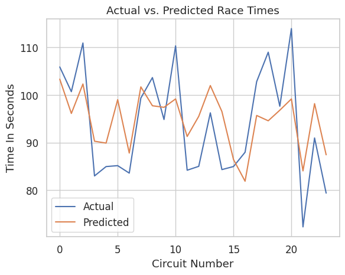

```python
plt.plot(circuit_errors['Actual'], label='Actual')
plt.plot(circuit_errors['Predicted'], label='Predicted')

plt.xlabel('Circuit Number')
plt.ylabel('Time In Seconds')
plt.legend()
plt.title('Actual vs. Predicted Race Times')
plt.grid(True)
plt.show()
```

This plot shows the circuit number, 1-24, and what time it takes to complete the course for each circuit. The reason for the line chart is that we wanted to show the difference between the actual and predicted race times based on each circuit. Some differences are more dramatic than others.

Ultimately, we feel that our model seems to have done a pretty good job mimicking the patterns in the data, without seeming super over-fit.

## Insights and Conclusions

Our goal for this project was to predict the average lap time of F1-based circuits based on track characteristics. We were successful in removing outliers that affected our model's preformance adversely, as some data was not quite accurate. Our charts and visuals depicted small deviations, and no extreme outliers were present after the data cleaning and some initial model analysis, We learned that using KNearest-Neighbors had the best preformance, at an error rate of around 8 seconds on average for prediction accuracy. Ultimately, this suggests that certain tracks are closely timed to similar tracks with similar features. We found that our model generalized well, even though it underfits a bit. We figured that this is better than overfitting and getting an inacurate model. Ultimately, we learned that predicting circuit performance is feasible with a well-curated and cleaned dataset. While smaller than we would have hoped, we were able to pretty accurately model a track's time based on a small number of features. Increasing the amount of features in our analysis would probably increase the accuracy of our model.